# Predict Bike Sharing Demand with AutoGluon Template

## Step 7: Write a Report

### Refer to the markdown file for the full report

### Creating plots and table for report

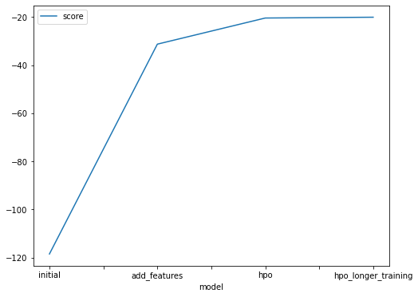

```python
# Taking the top model score from each training run and creating a line plot to show improvement
# You can create these in the notebook and save them to PNG or use some other tool (e.g. google sheets, excel)
fig = pd.DataFrame(
    {
        "model": ["initial", "add_features", "hpo", "hpo_longer_training"],
        "score": [-118.456660, -31.235420, -20.372547, -20.036898]
    }
).plot(x="model", y="score", figsize=(8, 6)).get_figure()
fig.savefig('img/model_train_score.png')
```

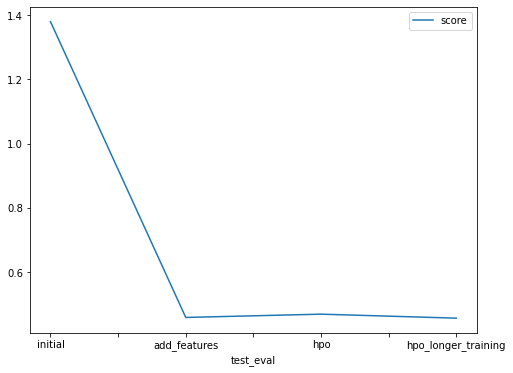

```python
# Take the 3 kaggle scores and creating a line plot to show improvement
fig = pd.DataFrame(
    {
        "test_eval": ["initial", "add_features", "hpo", "hpo_longer_training"],
        "score": [1.37974, 0.45910, 0.46934, 0.45688]

    }
).plot(x="test_eval", y="score", figsize=(8, 6)).get_figure()
fig.savefig('img/model_test_score.png')
```

### Hyperparameter table

```python
# hyperparameters we tuned with the kaggle score as the result
pd.DataFrame({
    "model": ["initial", "add_features", "hpo1", "hpo2", "hpo3", "hpo4"],
    "eval_metric": ["root_mean_squared_error", "root_mean_squared_error", "mean_absolute_error", "root_mean_squared_error", "r2", "mean_absolute_error"],
    "presets": ["best_quality", "best_quality", "best_quality", "best_quality", "best_quality", "best_quality"],
    "training_time": [600, 600, 600, 600, 600, 3600],
    "score": [1.37974, 0.45910, 0.46934, 0.51804, 0.51596, 0.45688]
})
```

|  | model | eval_metric | presets | training_time | score |
| --- | --- | --- | --- | --- | --- |
| 0 | initial | root_mean_squared_error | best_quality | 600 | 1.37974 |
| 1 | add_features | root_mean_squared_error | best_quality | 600 | 0.45910 |
| 2 | hpo1 | mean_absolute_error | best_quality | 600 | 0.46934 |
| 3 | hpo2 | root_mean_squared_error | best_quality | 600 | 0.51804 |
| 4 | hpo3 | r2 | best_quality | 600 | 0.51596 |
| 5 | hpo4 | mean_absolute_error | best_quality | 3600 | 0.45688 |

## Appendix - Explaining AutoGluon-Tabular Predictions with KernSHAP

I thought I would do some investigation work on feature importance.

Based on https://github.com/awslabs/autogluon/blob/master/examples/tabular/interpret/SHAP%20with%20AutoGluon-Tabular%20Diabetes%20regression.ipynb this section is explaining the predictions using Shapely values. [Shapely values](https://papers.nips.cc/paper/7062-a-unified-approach-to-interpreting-model-predictions.pdf) quantify how much each feature contributed to a particular AutoGluon-prediction deviating from some "baseline" value. I used the [Kernel SHAP variant](https://shap.readthedocs.io/en/latest/generated/shap.KernelExplainer.html) which is appropriate for explaining arbitrary black-box models like the potentially heterogeneous ensemble of many models that AutoGluon-Tabular uses to make its predictions.

You must first install the [SHAP package](https://github.com/slundberg/shap/) (`pip install shap`).

```python
from autogluon.tabular import TabularPredictor
import pandas as pd
import numpy as np
import sklearn
import shap
import time

shap.initjs()

import warnings
warnings.filterwarnings('ignore')
```

```python
X,y = shap.datasets.diabetes()
X = pd.read_csv('data/train.csv', parse_dates=['datetime'])
y = X['count']
X = X.drop(columns=['casual', 'registered', 'count'])
X['month'] = X['datetime'].dt.month
X['hour'] = X['datetime'].dt.hour
X['dayofweek'] = X['datetime'].dt.dayofweek
X['datetime'] = (X['datetime'] - pd.Timestamp("1970-01-01")) // pd.Timedelta('1s') # convert to seconds as SHAP is expecting only numbers

X_train,X_valid,y_train,y_valid = sklearn.model_selection.train_test_split(X, y, test_size=0.2, random_state=0)

def print_accuracy(f):
    print("Root mean squared test error = {0}".format(np.sqrt(np.mean((f(X_valid) - y_valid)**2))))
    time.sleep(0.5) # to let the print get out before any progress bars
```

### Train AutoGluon regressor

Here we just train directly on the raw data, without any normalizations. We first format the data in a manner suitable for AutoGluon training (pandas DataFrame):

```python
label = 'count'
feature_names = X_train.columns
train_data = X_train.copy()
train_data[label] = y_train
val_data = X_valid.copy()

display(train_data.head())
```

|  | datetime | season | holiday | workingday | weather | temp | atemp | humidity | windspeed | month | hour | dayofweek | count |
| --- | --- | --- | --- | --- | --- | --- | --- | --- | --- | --- | --- | --- | --- |
| 3662 | 1315051200 | 3 | 0 | 0 | 1 | 28.70 | 32.575 | 61 | 15.0013 | 9 | 12 | 5 | 257 |
| 8648 | 1343926800 | 3 | 0 | 1 | 1 | 33.62 | 38.635 | 52 | 16.9979 | 8 | 17 | 3 | 865 |
| 7053 | 1334210400 | 2 | 0 | 1 | 1 | 12.30 | 14.395 | 65 | 16.9979 | 4 | 6 | 3 | 96 |
| 2685 | 1308510000 | 2 | 0 | 0 | 1 | 29.52 | 34.090 | 62 | 8.9981 | 6 | 19 | 6 | 311 |
| 5927 | 1328241600 | 1 | 0 | 1 | 1 | 10.66 | 12.880 | 60 | 15.0013 | 2 | 4 | 4 | 2 |

```python
predictor = TabularPredictor(label=label, problem_type='regression').fit(train_data, time_limit=20)
```

[output not shown]

```
[1000]	train_set's rmse: 29.7861	valid_set's rmse: 35.9845
[2000]	train_set's rmse: 24.9162	valid_set's rmse: 34.7387
[3000]	train_set's rmse: 22.1503	valid_set's rmse: 34.3514
[4000]	train_set's rmse: 20.213	valid_set's rmse: 34.2484
```

```
	-34.2349	 = Validation score   (root_mean_squared_error)
	7.52s	 = Training   runtime
	0.16s	 = Validation runtime
Fitting model: LightGBM ... Training model for up to 11.67s of the 11.66s of remaining time.
```

```
[1000]	train_set's rmse: 18.5259	valid_set's rmse: 33.6463
```

```
	-33.5383	 = Validation score   (root_mean_squared_error)
	1.84s	 = Training   runtime
	0.02s	 = Validation runtime
Fitting model: RandomForestMSE ... Training model for up to 9.71s of the 9.69s of remaining time.
	-38.0464	 = Validation score   (root_mean_squared_error)
	2.39s	 = Training   runtime
	0.07s	 = Validation runtime
Fitting model: CatBoost ... Training model for up to 6.75s of the 6.74s of remaining time.
	-33.2893	 = Validation score   (root_mean_squared_error)
	5.72s	 = Training   runtime
	0.0s	 = Validation runtime
Fitting model: ExtraTreesMSE ... Training model for up to 1.01s of the 1.0s of remaining time.
	-38.1253	 = Validation score   (root_mean_squared_error)
	1.3s	 = Training   runtime
	0.06s	 = Validation runtime
Fitting model: WeightedEnsemble_L2 ... Training model for up to 19.82s of the -1.97s of remaining time.
	-31.777	 = Validation score   (root_mean_squared_error)
	0.3s	 = Training   runtime
	0.0s	 = Validation runtime
AutoGluon training complete, total runtime = 22.33s ...
TabularPredictor saved. To load, use: predictor = TabularPredictor.load("AutogluonModels/ag-20211206_113655/")
```